[figure not shown]

# Finding the Best Pokemon Team Composition

**An Inspirational CMSC320 Project by Devan Tamot**

## Introduction

Hello there! It's so very nice to meet you! Welcome to the world of Pokemon! My name is Devan Tamot, however everyone just calls me the Pokemon Professor. This world is widely inhabited by creatures known as Pokemon. We Humans live alongside Pokemon as friends. At times we play together, and at other times we work together. Some people use their Pokemon to battle and develop closer bonds with them. What do I do? I conduct data science research so we learn more about Pokemon and how to best utilize their strengths and weaknesses.

As an well established Pokemon Professor who happens to be a Computer Science genius, I wanted to make this project about finding the optimal team given various senarios such as a set of pokemon to battle, a set of elements, etc. When first playing a Pokemon game, it can be quite overwhelming at first because so much information is being thrown at you. My hopes is that this notebook will help anyone who is looking for the most optimal team so they can become a Pokemon Master!

This project does not consider movesets that act as buffs for pokemon (aka moves that enable special stats like a power up, defense up, etc..)

## Getting Started with the Data

I used Python3 and the following libraries: [requests](https://2.python-requests.org/en/master/), [io](https://docs.python.org/2/library/io.html), [pandas](https://pandas.pydata.org/), [pprint](https://docs.python.org/2/library/pprint.html), [graphviz](https://graphviz.readthedocs.io/en/stable/api.html)

```python
# These are the nessessary initalization imports needed
import requests, io
import pandas as pd
import pprint, random
from graphviz import Digraph
# Must run the following commands in docker:
# 1. pip install graphviz
# 2. conda install python-graphviz
import numpy as np
import pandas as pd
import matplotlib as plt

import seaborn as sns
import random

# These aren't directly important, but they are just for looks
from ipywidgets import IntProgress
import ipywidgets as widgets
from IPython.display import Image, display
import time, psutil
```

The data set I will be using is a RESTful API called the [PokeApi](https://pokeapi.co/) which contains JSON data about all things Pokemon.

```python
j = requests.get('https://pokeapi.co/api/v2/pokemon/').json()
# pprint.pprint(j) # To see the json data
```

### Elemental Dependency Digraph

In order to effectively calculate the most effective team, we need some sort of data structure to maintain the relationships between the elemental types. An edge connection from one node to another means that the starting elemental type is super effective against the ending elemental node. One way to represent this is as a Weighted Digraph as such:

[figure not shown]

```python
wed = dict() # Weighted Elemental Digraph
# Function for adding relationships to wed
# Parameters: from, to, weight
def addToWed(f,t,w):
    if(f not in wed):
        wed[f] = dict()
    wed[f][t]=w
def getFactor(f,t):
    if t not in wed[f]:
        return 0
    return wed[f][t]
# returns a list of elements that it is super effective against
def getTimesTwoElements(f):
    returnList = []
    for e in wed[f]:
        if wed[f][e] == 2:
            returnList.append(e)
    return returnList

j = requests.get('https://pokeapi.co/api/v2/type/').json()

for t in j['results'][:-2]:
    type_info = requests.get('https://pokeapi.co/api/v2/type/'+t['name']).json()
    for k in type_info['damage_relations']['double_damage_from']:
        addToWed(k['name'],t['name'],2)
    for k in type_info['damage_relations']['double_damage_to']:
        addToWed(t['name'],k['name'],2)
    for k in type_info['damage_relations']['half_damage_from']:
        addToWed(k['name'],t['name'],0.5)
    for k in type_info['damage_relations']['half_damage_to']:
        addToWed(t['name'],k['name'],0.5)
    for k in type_info['damage_relations']['no_damage_from']:
        addToWed(k['name'],t['name'],0)
    for k in type_info['damage_relations']['no_damage_to']:
        addToWed(t['name'],k['name'],0)
```

Just to prove that the digraph just created produced the proper digraph, here is a graph visualization down below.

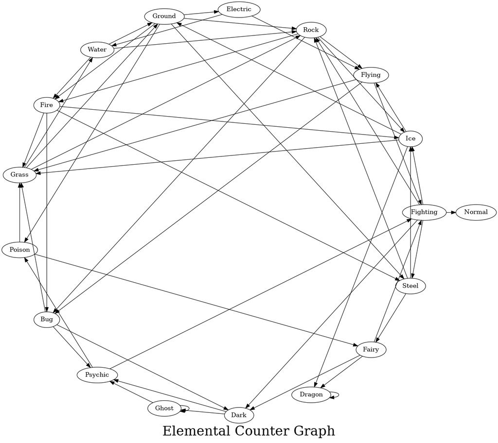

```python
dom_graph = Digraph(name='dom-graph',strict=True,graph_attr={'fontsize':'30pt'})
dom_graph.attr(label='Elemental Counter Graph',layout="circo",overlap='false')

for k,v in wed.items():
    dom_graph.node(k,k.capitalize())
    for e in getTimesTwoElements(k):
        dom_graph.node(e,e.capitalize())
        ed = dom_graph.edge(k,e)

dom_graph.render('graph-viz/elemental_graph.gv', view=True,format='png')
display(Image(filename='graph-viz/elemental_graph.gv.png',width='700pt',height='700pt'))
```

### Precomputation of Data

In order to prevent continually looking up pokemon data when we need it, I decided to precompute the data by populating a python dictonary with the nessessary information needed.

### Attack Move Data

The first step in finding the best pokemon team is to the gather information about each move. This includes its name, elemental type, and power.

```python
# Precompuation of the moves from the API is nessessary to avoid having to make
# Multiple calls
moveDict = dict() # Dictionary of moves [name|->(element, damage)]
j = requests.get('https://pokeapi.co/api/v2/move').json()

print('Loading all Move Data ... ')
max_count = j['count']
f = IntProgress(min=0, max=max_count) # instantiate the bar
display(f) # display the bar

while(j['next']!=None):
    for m in j['results']:
        f.value += 1 # signal to increment the progress bar
        mInfo = requests.get(m['url']).json()
        if(mInfo['power'] != None):
            moveDict[m['name']]=(mInfo['type']['name'],mInfo['power'])
    j=requests.get(j['next']).json()
print('Loaded',max_count,'Moves!')
```

```
Loading all Move Data ...
```

```
Loaded 746 Moves!
```

### Pokemon Data

#### Legendary Pokemon

These pokemon are considered legendary according to the Pokemon Lore. For most pokemon battle competitions, the use of Legendary pokemon is banned. Therefore, I offer the option to filter out lengendary pokemon for finding an optimal team.

#### Pokemon Data Structure

In order to maintain all pokemon information in a useful neat way, I created a Pokemon object type that maintains a Pokemon's name, id, elemental types, and moves.

#### Creating the Complete Pokemon Roster

As before with the move dictionary, I front load all the GET requests a head of time to prevent a culter of GET calls later on. This takes quite a bit of time to load all 800+ Pokemon.

```python
# Maintains a list of all legendary Pokemon IDs
legendaryIDList = [144, 145, 146, 150, 151, 243, 244, 245, 249, 250,
                   251, 377, 378, 379, 380, 381, 382, 383, 384, 385,
                   386, 480, 481, 482, 483, 484, 485, 486, 487, 488,
                   489, 490, 491, 492, 493, 494, 638, 639, 640, 641,
                   642, 643, 644, 645, 646, 647, 648, 649]
elAllList = ['normal','fighting','flying','poison','ground','rock','bug','ghost','steel',
          'fire','water','grass','electric','psychic','ice','dragon','dark','fairy']
class Pokemon:
    def __init__(self,name,idn,elements,moves,atk,spd,dfn):
        self.name = name
        self.idn = idn
        self.elements = elements
        self.moves = moves # dict mapping [moveName|->(element,damage)]
        self.atk = atk
        self.spd = spd
        self.dfn = dfn
        sum=0
        for m,s in moves.items():
            for e in elAllList:
                sum += getFactor(s[0],e)
        self.sum = sum

    def getElementalSum(e):
        sum = 0
        for m in moves:
            sum += getFactor(m,e)
        return sum
    def getType(self):
        return '/'.join(self.elements)

# Now we begin creating the ultimate pokemon roster
pkmRoster = dict()

j = requests.get('https://pokeapi.co/api/v2/pokemon').json()

print('Loading all Pokemon Data ...')

max_count = 807
f = IntProgress(min=0, max=max_count) # instantiate the bar
display(f) # display the bar

while(j['next']!=None):
    for p in j['results']:
        f.value += 1 # signal to increment the progress bar
        pinfo = requests.get('https://pokeapi.co/api/v2/pokemon/'+p['name']).json()
        if(pinfo['id'] < 808):
            types = []
            for t in pinfo['types']:
                types.append(t['type']['name'])
            moves=dict()
            for m in pinfo['moves']:
                if m['move']['name'] in moveDict:
                    moves[m['move']['name']] = moveDict[m['move']['name']]
            pokeObj = Pokemon(p['name'],pinfo['id'],types,moves,pinfo['stats'][4]['base_stat'],pinfo['stats'][0]['base_stat'],pinfo['stats'][3]['base_stat'])
            #pprint.pprint(moves)
            pkmRoster[p['name']] = pokeObj
    j=requests.get(j['next']).json()

print('Loaded',max_count,"Pokemon!")
```

```
Loading all Pokemon Data ...
```

```
Loaded 807 Pokemon!
```

## Exploratory Data Analysis

### Elemental Type Background

[output not shown]

When Pokemon are in battle, the attacking Pokemon can choose an attack from a moveset of 4 different attacks. These attacks do not nessessiarily have to be the same type of the pokemon, they can be different types. When an attack is executed on a defending Pokemon, the amount of damage done to the defending Pokemon depends on the elemental type of the attack and the elemental type of the defending Pokemon.

With these elemental strengths known, we can actually look up the weighted effectiveness of each elemental moveset against the others. The image below shows the elemental relationships:

[figure not shown]

For example, based on the graph we see that water types do times 2 damage against Fire, Ground, and Rock type pokemon.

### Algorithms

#### getSortedElList()

> **Parameters:**

> > **elList**: a list of elements that need to be countered  
> > **noLegend**: determines if we want to include legendary pokemon or not

> **Output:**

> > A list of tuples in the form *(pokemon_name,move_sum)*

> **Algorithm:**

> > This function simply gets a sorted list of the pokemon with the moveset that will best counter the element list provided

> > ```
> >            fun getSortedElList(elList, noLegend):
> >                 Let L be a sorted list that will maintain the top ranked pokemon
> >                 for each pokemon in the pokemon roster:
> >                   If the pokemon satisfies the noLegend parameter:
> >                       count all the elements the pokemon can counter with it's moves
> >                       then append (pokemon_name,sum) to L
> >                   end if
> >                 end for
> >                 return a L sorted by the sum of each pokemon
> >             end fun
> > ```

#### getBestMoveSet()

> **Parameters:**

> > **P**: a list of *n* pokemon that will be used to counter the elements in elList  
> > **elList**: a list of elements that need to be countered **shareMoves**: a boolean variable that will determine if Pokemon in the list are allowed to share moves

> **Output:**

> > A dictionary that maps [**Pokemon**]→[**list_of_move_names**]]

> **Algorithm:**

> > This function simply maps a set of moves to each pokemon provided

> > ```
> >             fun getBestMoveSet(P, elList):
> >                 Let E be an empty dictionary which maps elemental types in elList to a list of tulples
> >                 let P be an empty dictionary which maps a pokemon from P to a list of moves
> >                 for each pokemon in P:
> >                     for each of the pokemon's moves:
> >                         if it is effective against any of the elements e in elList:
> >                             E[e] = (pokemon_name,move_name,move_damage)
> >                         end if
> >                     end for
> >                 end for
> >
> >                 for each key e in E:
> >                     sort E[e] based on attack power
> >                 end for
> >                 for each of the element keys in E starting with the one with the least moves in it's move list:
> >                     Take the top move from it's move list:
> >                         If the pokemon that has that move still has room for moves:
> >                             add that move to the pokemon's move list in P
> >                             exit the loop
> >                         else:
> >                             remove the move and keep looking
> >                         end if
> >                     end loop
> >                  end for
> >                  return P
> >             end fun
> > ```

```python
legendaryIDList = [144, 145, 146, 150, 151, 243, 244, 245, 249, 250,
                   251, 377, 378, 379, 380, 381, 382, 383, 384, 385,
                   386, 480, 481, 482, 483, 484, 485, 486, 487, 488,
                   489, 490, 491, 492, 493, 494, 638, 639, 640, 641,
                   642, 643, 644, 645, 646, 647, 648, 649]
# get the last key.
def last(n):
    return n[-1]

# function to sort the tuple
def sort(tuples):

    # We pass used defined function last
    # as a parameter.
    return sorted(tuples, key = last)

# This function ranks all pokemon based on how effective they are against a list of elements
def getSortedElList(elList,noLegend):
    L = [] # A sorted list that will maintain the top ranked pokemon for this list
    for p,v in pkmRoster.items():
        sum = 0
        if(noLegend):
            if (v.idn not in legendaryIDList):
                for m,s in v.moves.items():
                    for e in elList:
                        sum += getFactor(s[0],e)
                L.append((p,sum))
        else:
            for m,s in v.moves.items():
                for e in elList:
                    sum += getFactor(s[0],e)
            L.append((p,sum))


    return sort(L)

# Given a set of Pokemon, this computes the best move set to counter a given set of elemental types
def getBestMoveSet(P,elList,shareMoves=True):

    # Create empty buckets for each pokemon
    elBuckets = dict()
    for e in elList:
        elBuckets[e] = []

    # go through each of the pokemons moves and determine if it has any
    # that are super effective against the elList elements
    pBuckets = dict()
    for p in P:
        pBuckets[p] = []
        poke = pkmRoster[p]
        for m,v in poke.moves.items():
            superEff = getTimesTwoElements(v[0])
            for s in superEff:
                if s in elList:
                    elBuckets[s].append((p,m,v[1]))

    # sort each move based on it's attack power
    for e,l in elBuckets.items():
        elBuckets[e] = sort(elBuckets[e])

    # Now selects which pokemon should get each one
    elPriorityList = []
    for el in elList:
        elPriorityList.append((el,len(elBuckets[el])))
    elPriorityList = sort(elPriorityList)

    moveList = []
    # now pairing the right movesets to each pokemon in the team
    for el in elPriorityList:
        if(len(elBuckets[el[0]]) != 0):
            count = -1
            validMove = False

            while(not validMove):
                potentialMove = elBuckets[el[0]][count]
                if (len(pBuckets[potentialMove[0]]) != 4) and (potentialMove[1] not in pBuckets[potentialMove[0]]):
                    if(potentialMove[1] in moveList):
                        if(shareMoves):
                            pBuckets[potentialMove[0]].append(potentialMove[1])
                            del elBuckets[el[0]][count] # removes the move from the list
                    else:
                        pBuckets[potentialMove[0]].append(potentialMove[1])
                        moveList.append(potentialMove[1])
                        del elBuckets[el[0]][count] # removes the move from the list
                    validMove = True
                else:
                    count -= 1
                    # incase we cannot find a move that satisfies this
                    if len(elBuckets[el[0]])+count < 0:
                        validMove = True

    return pBuckets

# creates and renders a graph based on the pokemon list
def createGraph(elList,pBuck,fileName,graphLabel='Pokemon Move to Type Dominance'):
    # Creating graphical list
    moveGraph = Digraph(name='move-graph',strict=True,graph_attr={'fontsize':'30pt'})
    moveGraph.attr(label=graphLabel)

    # add the elemental types to counter
    for e in elList:
        moveGraph.node(e,e.capitalize())

    # Add the pokemon
    for p,m in pBuck.items():
        moveGraph.node(p,p.capitalize()+'\n('+pkmRoster[p].getType()+')')
        for subM in m:

            moveGraph.node(subM,subM.capitalize()+'\n('+moveDict[subM][0]+')')
            moveGraph.edge(p,subM,constraint='true',concentrate='false')

            # Now we add the type dominances per move
            domElements = getTimesTwoElements(moveDict[subM][0])
            for dE in domElements:
                if dE in elList:
                    moveGraph.edge(subM,dE,constraint='true',concentrate='false')
    # Render the graph
    moveGraph.render(fileName, view=True,format='png')
```

Using the functions from above, we can break it down into these simple steps:

Note that some Pokemon do not have all 4 moves filled. This is due to all the elements being fufilled by the current moveset, therefore, it would be unnessessary for the other pokemon to have any extra moves. This essentially means those pokemon can have any moves.

[figure not shown]

[figure not shown]

```python
elList = ['normal','fighting','flying','poison','ground','rock','bug','ghost','steel',
          'fire','water','grass','electric','psychic','ice','dragon','dark','fairy']

P = getSortedElList(elList,noLegend=True)
pBuck = getBestMoveSet([i[0] for i in P[-6:]],elList,shareMoves=False)
createGraph(elList,pBuck,'graph-viz/pokeGraphNoLegend.gv',graphLabel='Optimal Unique Team/Moves no Legendaries')

PL = getSortedElList(elList,noLegend=False)
pBuckL = getBestMoveSet([i[0] for i in PL[-6:]],elList,shareMoves=False)
createGraph(elList,pBuckL,'graph-viz/pokeGraphWithLegend.gv',graphLabel='Optimal Unique Team/Moves with Legendaries')

listOfImageNames = ['graph-viz/pokeGraphNoLegend.gv.png',
                    'graph-viz/pokeGraphWithLegend.gv.png']

for imageName in listOfImageNames:
    display(Image(filename=imageName))
```

The Graphs below demonstrates the same as above except Pokemon are allowed to have the same move sets as one another

[figure not shown]

[figure not shown]

```python
P = getSortedElList(elList,noLegend=True)
pBuck = getBestMoveSet([i[0] for i in P[-6:]],elList,shareMoves=True)
createGraph(elList,pBuck,'graph-viz/pokeGraphNoLegend.gv',graphLabel='Optimal Team/Moves no Legendaries')

PL = getSortedElList(elList,noLegend=False)
pBuckL = getBestMoveSet([i[0] for i in PL[-6:]],elList,shareMoves=True)
createGraph(elList,pBuckL,'graph-viz/pokeGraphWithLegend.gv',graphLabel='Optimal Team/Moves with Legendaries')

listOfImageNames = ['graph-viz/pokeGraphNoLegend.gv.png',
                    'graph-viz/pokeGraphWithLegend.gv.png']

for imageName in listOfImageNames:
    display(Image(filename=imageName))
```

Just for fun, I created a custom team selector that allows you to pick any team of pokemon and find the optimal moveset for that team.

```python
current_display = False
elAllList = ['normal','fighting','flying','poison','ground','rock','bug','ghost','steel',
          'fire','water','grass','electric','psychic','ice','dragon','dark','fairy']
capPokeRoster = list(map(lambda x:x.capitalize(),list(pkmRoster.keys())))

def on_team_click(s):
    global current_display
    team = []
    for i in range(6):
        if items[i].value != '' and items[i].value.lower() in pkmRoster.keys():
            team.append(items[i].value.lower())
    pBuck = getBestMoveSet(team,elAllList,shareMoves=checkBox.value)
    createGraph(elList,pBuck,'graph-viz/customTeam.gv',graphLabel='Custom Team Comp')

    if(current_display):
        for proc in psutil.process_iter():
            if proc.name() == "display":
                proc.kill()

    file = open("graph-viz/customTeam.gv.png", "rb")
    image = file.read()
    wimage = widgets.Image(
        value=image,
        format='png',
        width=1000,
        height=700,
    )
    current_display = True
    display(wimage)

def on_rand_click(s):
    for i in range(6):
        items[i].value = capPokeRoster[random.randint(0,len(capPokeRoster))]

items = [widgets.Combobox(
        value=None,
        placeholder='Choose a Pokemon',
        options=capPokeRoster,
        description='Pokemon # '+str(i+1),
        ensure_option=True,
        disabled=False
    ) for i in range(6)]

checkBox = widgets.Checkbox(
    value=False,
    description='Share Moves',
    disabled=False)

butt = widgets.Button(description="View Move Graph")
randButt = widgets.Button(description="Choose Random",color='blue')
items.append(widgets.HBox([butt,randButt,checkBox]))
butt.on_click(on_team_click)
randButt.on_click(on_rand_click)
widgets.VBox(items)
```

Now that we have some form of visual representation, lets dive into win percentages of pokemon and see statisics says about our team composition.

## Getting back into the Data

To figure out win percentages, I use some data that I found [online](https://www.kaggle.com/mmetter/pokemon-data-analysis-tutorial/data). Unfortunetly, the Pokemon data does not align exactly to the offical pokedex, so I had to use theirs to maintain consistency.

The battle data information was crafted from a battle algorithm that ran simulations for battles.

```python
combat = pd.read_csv("combats.csv")
pokeDF = pd.read_csv("pokemon.csv")

for index, row in pokeDF.iterrows():
    if type(row['Name']) == type('') and row['Name'].lower() in pkmRoster:
        pokeDF.loc[index,'move_sum'] = pkmRoster[row['Name'].lower()].sum

pokeDF.head()
```

|  | # | Name | Type 1 | Type 2 | HP | Attack | Defense | Sp. Atk | Sp. Def | Speed | Generation | Legendary | move_sum |
| --- | --- | --- | --- | --- | --- | --- | --- | --- | --- | --- | --- | --- | --- |
| 0 | 1 | Bulbasaur | Grass | Poison | 45 | 49 | 49 | 65 | 65 | 45 | 1 | False | 197.0 |
| 1 | 2 | Ivysaur | Grass | Poison | 60 | 62 | 63 | 80 | 80 | 60 | 1 | False | 151.0 |
| 2 | 3 | Venusaur | Grass | Poison | 80 | 82 | 83 | 100 | 100 | 80 | 1 | False | 207.0 |
| 3 | 4 | Mega Venusaur | Grass | Poison | 80 | 100 | 123 | 122 | 120 | 80 | 1 | False | NaN |
| 4 | 5 | Charmander | Fire | NaN | 39 | 52 | 43 | 60 | 50 | 65 | 1 | False | 358.5 |

Now to calculate win percentages for each Pokemon.

```python
# This will calculate the win percentages of each pokemon and add it to the data set
total_Wins = combat.Winner.value_counts()
# get the number of wins for each pokemon
numberOfWins = combat.groupby('Winner').count()
countByFirst = combat.groupby('Second_pokemon').count()
countBySecond = combat.groupby('First_pokemon').count()

numberOfWins['Total Fights'] = countByFirst.Winner + countBySecond.Winner
numberOfWins['Win Percentage']= numberOfWins.First_pokemon/numberOfWins['Total Fights']

# merge the win percentage dataset with the original dataset
pokeDF = pd.merge(pokeDF, numberOfWins, left_on='#', right_index = True, how='left')

pokeDF.head()
```

|  | # | Name | Type 1 | Type 2 | HP | Attack | Defense | Sp. Atk | Sp. Def | Speed | Generation | Legendary | move_sum | First_pokemon | Second_pokemon | Total Fights | Win Percentage |
| --- | --- | --- | --- | --- | --- | --- | --- | --- | --- | --- | --- | --- | --- | --- | --- | --- | --- |
| 0 | 1 | Bulbasaur | Grass | Poison | 45 | 49 | 49 | 65 | 65 | 45 | 1 | False | 197.0 | 37.0 | 37.0 | 133.0 | 0.278195 |
| 1 | 2 | Ivysaur | Grass | Poison | 60 | 62 | 63 | 80 | 80 | 60 | 1 | False | 151.0 | 46.0 | 46.0 | 121.0 | 0.380165 |
| 2 | 3 | Venusaur | Grass | Poison | 80 | 82 | 83 | 100 | 100 | 80 | 1 | False | 207.0 | 89.0 | 89.0 | 132.0 | 0.674242 |
| 3 | 4 | Mega Venusaur | Grass | Poison | 80 | 100 | 123 | 122 | 120 | 80 | 1 | False | NaN | 70.0 | 70.0 | 125.0 | 0.560000 |
| 4 | 5 | Charmander | Fire | NaN | 39 | 52 | 43 | 60 | 50 | 65 | 1 | False | 358.5 | 55.0 | 55.0 | 112.0 | 0.491071 |

We can actually see the win percentages per elemental type.

```python
grouped = pokeDF.groupby('Type 1').agg({"Win Percentage": "mean"}).sort_values(by = "Win Percentage")
grouped
```

| Type 1 | Win Percentage |
| --- | --- |
| Fairy | 0.329300 |
| Rock | 0.404852 |
| Steel | 0.424529 |
| Poison | 0.433262 |
| Bug | 0.439006 |
| Ice | 0.439604 |
| Grass | 0.440364 |
| Water | 0.469357 |
| Fighting | 0.475616 |
| Ghost | 0.484027 |
| Normal | 0.535578 |
| Ground | 0.541526 |
| Psychic | 0.545747 |
| Fire | 0.579215 |
| Dark | 0.629726 |
| Electric | 0.632861 |
| Dragon | 0.633587 |
| Flying | 0.765061 |

## Data Analysis and Linear Regression Modeling

Now that we have a visual way of seeing how a team will match up against the different elemental types, lets see which other factors will help a Pokemon team win a battle.

To make things interesting, lets call back onto our elemental digraph to see correlation between win percentage and elemental advantage.

```python
new_dict = dict.fromkeys(elAllList, 0)
for p,o in pkmRoster.items():
    new_dict[o.elements[0]] += o.sum
typeDF = pd.DataFrame(columns=['Type','Win Percentage','Sum'])
for e in elAllList:
    typeDF = typeDF.append({'Type':e,'Win Percentage':grouped.loc[e.capitalize()]['Win Percentage'],'Sum':new_dict[e]},ignore_index=True)
typeDF.head(len(elAllList))
```

|  | Type | Win Percentage | Sum |
| --- | --- | --- | --- |
| 0 | normal | 0.535578 | 15826.0 |
| 1 | fighting | 0.475616 | 13518.5 |
| 2 | flying | 0.765061 | 18823.0 |
| 3 | poison | 0.433262 | 8650.0 |
| 4 | ground | 0.541526 | 11774.0 |
| 5 | rock | 0.404852 | 6354.0 |
| 6 | bug | 0.439006 | 2933.5 |
| 7 | ghost | 0.484027 | 4537.0 |
| 8 | steel | 0.424529 | 5110.5 |
| 9 | fire | 0.579215 | 9643.5 |
| 10 | water | 0.469357 | 17090.0 |
| 11 | grass | 0.440364 | 10125.0 |
| 12 | electric | 0.632861 | 5830.5 |
| 13 | psychic | 0.545747 | 12350.5 |
| 14 | ice | 0.439604 | 4851.0 |
| 15 | dragon | 0.633587 | 6383.0 |
| 16 | dark | 0.629726 | 6236.0 |
| 17 | fairy | 0.329300 | 7885.0 |

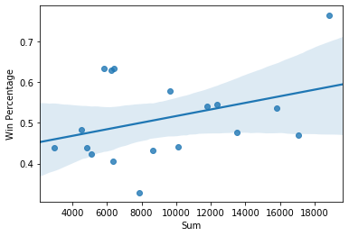

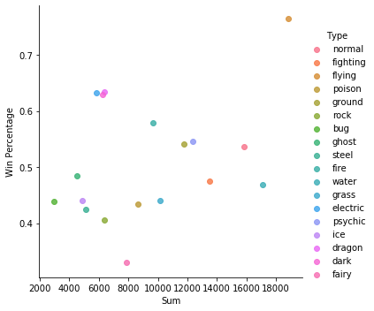

```python
# typeDF.plot(x="Sum",y="Win Percentage",style='o')
sns.regplot(x="Sum", y="Win Percentage", data=typeDF, fit_reg =True)#.set_title("Elemental Move Sum vs Win Percentage")
sns.lmplot(x="Sum", y="Win Percentage", data=typeDF, hue = 'Type',fit_reg =False)#.set_title("Elemental Move Sum vs Win Percentage")
```

The plot above shows the relation between the total elemental effectiveness of each Pokemon per type. As we can see, the plot points show the higher the elemental sum is for a pokemon of a certain type, the higher chance your pokemon has to win.

Going back to the optimal team from above, let us use this new data to find the winning percentage of a given team composition. To do that, we need to consider what stats we want to use based on how each stat correlates to the Winning Percentage.

As we can see below, the Speed and Attack stat seems to make the best linear regression models. Defense is not the worst, however it does not look as sharp as the speed and attack stats, so we will not use defense in our prediction.

Since we will not be using defense, we will also not being using the Sum to Win Percentage regression from above.

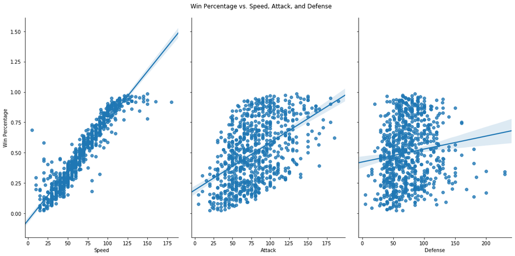

```python
ax_3pairs = sns.pairplot(pokeDF, x_vars=['Speed','Attack','Defense'], y_vars='Win Percentage', size=7, aspect=0.7, kind='reg')
ax_3pairs.fig.suptitle('Win Percentage vs. Speed, Attack, and Defense', y=1.03)
```

Below, we compute the slope and intercept for the Speed and Attack linear regression equations.

```python
import scipy
nanFree = pokeDF.dropna(axis=0)
speed_reg = scipy.stats.linregress(nanFree['Speed'], nanFree['Win Percentage'])
attack_reg = scipy.stats.linregress(nanFree['Attack'], nanFree['Win Percentage'])
print(speed_reg.slope,speed_reg.intercept)
print(attack_reg.slope,attack_reg.intercept)
```

```
0.008445397023413384 -0.06577521681567766
0.0037811902415860626 0.21119942359952426
```

Now that we have some way of predicting winning percentages for pokemon based on their stats, lets have a way to compute the winning percentages of a given pokemon team. The Team Winning percentage is based on the average winning percentage of the entire team.

```python
current_display = False
elAllList = ['normal','fighting','flying','poison','ground','rock','bug','ghost','steel',
          'fire','water','grass','electric','psychic','ice','dragon','dark','fairy']
capPokeRoster = list(map(lambda x:x.capitalize(),list(pkmRoster.keys())))

def compute_win(t):
    win_sum = 0
    for p in t:
        win_sum += pkmRoster[p].spd * speed_reg.slope + speed_reg.intercept
        win_sum += pkmRoster[p].atk * attack_reg.slope + attack_reg.intercept
    win_sum/= (2*len(t))
    return win_sum*100

def on_team_click(s):
    global current_display
    team = []
    for i in range(6):
        if items[i].value != '' and items[i].value.lower() in pkmRoster.keys():
            team.append(items[i].value.lower())

    pBuck = getBestMoveSet(team,elAllList,shareMoves=checkBox.value)
    createGraph(elList,pBuck,'graph-viz/customTeam.gv',graphLabel='Custom Team Comp: '+str(round(compute_win(team),2))+'% change of winning')

    if(current_display):
        for proc in psutil.process_iter():
            if proc.name() == "display":
                proc.kill()

    file = open("graph-viz/customTeam.gv.png", "rb")
    image = file.read()
    wimage = widgets.Image(
        value=image,
        format='png',
        width=1000,
        height=800,
    )
    current_display = True
    display(wimage)

def on_rand_click(s):
    for i in range(6):
        items[i].value = capPokeRoster[random.randint(0,len(capPokeRoster))]

items = [widgets.Combobox(
        value=None,
        placeholder='Choose a Pokemon',
        options=capPokeRoster,
        description='Pokemon # '+str(i+1),
        ensure_option=True,
        disabled=False
    ) for i in range(6)]

checkBox = widgets.Checkbox(
    value=False,
    description='Share Moves',
    disabled=False)

butt = widgets.Button(description="View Move Graph")
randButt = widgets.Button(description="Choose Random",color='blue')
items.append(widgets.HBox([butt,randButt,checkBox]))
butt.on_click(on_team_click)
randButt.on_click(on_rand_click)
widgets.VBox(items)
```

Now that we have some method of predicting the probability of a team composition winning, lets see how our previously determined optimal team composition does against this prediction model.

[figure not shown]

[figure not shown]

```python
elList = ['normal','fighting','flying','poison','ground','rock','bug','ghost','steel',
          'fire','water','grass','electric','psychic','ice','dragon','dark','fairy']

P = getSortedElList(elList,noLegend=True)

pBuck = getBestMoveSet([i[0] for i in P[-6:]],elList,shareMoves=False)
createGraph(elList,pBuck,'graph-viz/pokeGraphNoLegend.gv',graphLabel='Optimal Unique Team/Moves No Legendaries: '+str(round(compute_win([i[0] for i in P[-6:]]),2))+"%")

PL = getSortedElList(elList,noLegend=False)

pBuckL = getBestMoveSet([i[0] for i in PL[-6:]],elList,shareMoves=False)
createGraph(elList,pBuckL,'graph-viz/pokeGraphWithLegend.gv',graphLabel='Optimal Unique Team/Moves with Legendaries: '+str(round(compute_win([i[0] for i in PL[-6:]]),2))+"%")

listOfImageNames = ['graph-viz/pokeGraphNoLegend.gv.png','graph-viz/pokeGraphWithLegend.gv.png']

for imageName in listOfImageNames:
    display(Image(filename=imageName))
```

## Conclusion and Insights

After doing this project, I learned a lot about what it takes to design a battle system that cannot be exposed in video games. The game designers did a decent job on balancing out abilities, moves, and elemental power distribution across the 800+ Pokemon. Even after exploiting the correlation between speed and attack to winning percentage, I was only able to get my "most optimal team" winning percentage to about 2/3 of battles. Of course there are several other things that could be contributed into calculating a winning percentage per pokemon such as tactics, special stats, abilities, etc.. but this tutorial gave a decent insight on what pokemon features stand out the most.

I love Pokemon, and I always have since I was a kid. I am so glad I was able to use my data science skills as a Pokemon Professor to find an optimal Pokemon team composition. If you are just a causual player, take advantage of the custom team composition calculator and see how well your team is able to counter all elemental types! This tutorial was a load of fun to make and I hope it has some uses to all Pokemon Trainers!